# Homework assignment 2

Data Science and Machine Learning 2 - CEU 2018

Peter Paziczki

2018 április 3

## 0. Preparation

In the first two problems I will work with the medical appointment no-show dataset from ML1.

```r
library(data.table)
library(magrittr)
library(GGally)

data <- fread("../data/medical-appointments-no-show/no-show-data.csv")

# some data cleaning

## dropping columns that we don't need
data[, c("PatientId", "AppointmentID", "Neighbourhood") := NULL]

## setting the names of variables
setnames(data,
         c("No-show",
           "Age",
           "Gender",
           "ScheduledDay",
           "AppointmentDay",
           "Scholarship",
           "Hipertension",
           "Diabetes",
           "Alcoholism",
           "Handcap",
           "SMS_received"),
         c("no_show",
           "age",
           "gender",
           "scheduled_day",
           "appointment_day",
           "scholarship",
           "hypertension",
           "diabetes",
           "alcoholism",
           "handicap",
           "sms_received"))

# for binary prediction, the target variable must be a factor variable
data[, no_show := factor(no_show, levels = c("Yes", "No"))]
data[, handicap := ifelse(handicap > 0, 1, 0)]

# creating new variables (turning them into factor variables)
data[, gender := factor(gender)]
data[, scholarship := factor(scholarship)]
data[, hypertension := factor(hypertension)]
data[, alcoholism := factor(alcoholism)]
data[, handicap := factor(handicap)]

# creating date type variables
data[, scheduled_day := as.Date(scheduled_day)]
data[, appointment_day := as.Date(appointment_day)]

# creating a new variable showing the days passed since scheduing the visit
data[, days_since_scheduled := as.integer(appointment_day - scheduled_day)]

# cleaning up a little bit
data <- data[age %between% c(0, 95)] # dropping observations with irrational ages
data <- data[days_since_scheduled > -1] # dropping observations with false days_since_scheduled values
data[, c("scheduled_day", "appointment_day", "sms_received") := NULL] # don't need scheduled_day and appointment_day variables any more
```

Please find some summary statistics below of the data set:

```r
skimr::skim(data)
```

```
## Skim summary statistics
##  n obs: 110475
##  n variables: 9
##
## Variable type: factor
##      variable missing complete      n n_unique
##    alcoholism       0   110475 110475        2
##        gender       0   110475 110475        2
##      handicap       0   110475 110475        2
##  hypertension       0   110475 110475        2
##       no_show       0   110475 110475        2
##   scholarship       0   110475 110475        2
##                    top_counts ordered
##     0: 107115, 1: 3360, NA: 0   FALSE
##     F: 71799, M: 38676, NA: 0   FALSE
##     0: 108245, 1: 2230, NA: 0   FALSE
##     0: 88702, 1: 21773, NA: 0   FALSE
##  No: 88168, Yes: 22307, NA: 0   FALSE
##     0: 99614, 1: 10861, NA: 0   FALSE
##
## Variable type: integer
##              variable missing complete      n   mean    sd p0 p25 median
##                   age       0   110475 110475 37.06  23.08  0  18     37
##  days_since_scheduled       0   110475 110475 10.18  15.25  0   0      4
##              diabetes       0   110475 110475  0.072  0.26  0   0      0
##  p75 p100     hist
##   55   95 ▇▆▇▇▇▅▂▁
##   15  179 ▇▁▁▁▁▁▁▁
##    0    1 ▇▁▁▁▁▁▁▁
```

```r
## loading h2o library
library(h2o)
h2o.init()
```

```
##
## H2O is not running yet, starting it now...
##
## Note:  In case of errors look at the following log files:
##     C:\Users\User\AppData\Local\Temp\Rtmpq2ewAw/h2o_User_started_from_r.out
##     C:\Users\User\AppData\Local\Temp\Rtmpq2ewAw/h2o_User_started_from_r.err
##
##
## Starting H2O JVM and connecting: . Connection successful!
##
## R is connected to the H2O cluster:
##     H2O cluster uptime:         3 seconds 599 milliseconds
##     H2O cluster version:        3.16.0.2
##     H2O cluster version age:    4 months and 4 days !!!
##     H2O cluster name:           H2O_started_from_R_User_zrj600
##     H2O cluster total nodes:    1
##     H2O cluster total memory:   1.75 GB
##     H2O cluster total cores:    8
##     H2O cluster allowed cores:  8
##     H2O cluster healthy:        TRUE
##     H2O Connection ip:          localhost
##     H2O Connection port:        54321
##     H2O Connection proxy:       NA
##     H2O Internal Security:      FALSE
##     H2O API Extensions:         Algos, AutoML, Core V3, Core V4
##     R Version:                  R version 3.4.3 (2017-11-30)
```

`h2o` is running on my computer now, my computer is the one and only node in the cluster right now. I need to transform the data set from a data table object into a `h2o` frame, so `h2o` can process it.

```r
data <- as.h2o(data)
```

## 1. Deep learning with `h2o`

### 1.1 Create train / validation / test sets, cutting the data into 5% - 45% - 50% parts.

The idea behind splitting data into different set is that When having large datasets, n-fold cross validation can be computationally intensive, hence many times train/validation/test approach is used instead. However, cross validation can still be used to tune some of the hyperparameters.

```r
# splitting data into three parts, train, validation and test, 5%, 45% and 50% respectively
splitted_data <- h2o.splitFrame(data,
                                ratios = c(0.05, 0.45), # first part is 5%, second is 45%, third part is the rest
                                seed = 123)

data_train <- splitted_data[[1]]
data_valid <- splitted_data[[2]]
data_test <- splitted_data[[3]]

# making sure that the data has been split the way we wanted
nrow(data_train)
```

```
## [1] 5508
```

```r
nrow(data_valid)
```

```
## [1] 49793
```

```r
nrow(data_test)
```

```
## [1] 55174
```

### 1.2 Train a benchmark model of your choice using h2o (such as random forest, gbm or glm) and evaluate it on the validation set.

#### 1.2.1 Random forest as first benchmark model

```r
y <- "no_show"  # the outcome variable
X <- setdiff(names(data), y) # the variables we are going to use for prediction, excluding the outcome variable
```

```r
# random forests
rf_params <- list(ntrees = c(500), # number of trees to estimate
                  mtries = c(2, 3, 5)) # number of features that the algorithm can randomly consider at each split

rf_grid <- h2o.grid(x = X,
                    y = y,
                    training_frame = data_train,
                    algorithm = "randomForest",
                    nfolds = 5,
                    seed = 123,
                    hyper_params = rf_params)
h2o.getGrid(grid_id = rf_grid@grid_id, sort_by = "rmse", decreasing = FALSE)
```

```
## H2O Grid Details
## ================
##
## Grid ID: Grid_DRF_RTMP_sid_8760_2_model_R_1522787101052_1
## Used hyper parameters:
##   -  mtries
##   -  ntrees
## Number of models: 3
## Number of failed models: 0
##
## Hyper-Parameter Search Summary: ordered by increasing rmse
##   mtries ntrees                                                model_ids
## 1      2    500 Grid_DRF_RTMP_sid_8760_2_model_R_1522787101052_1_model_0
## 2      3    500 Grid_DRF_RTMP_sid_8760_2_model_R_1522787101052_1_model_1
## 3      5    500 Grid_DRF_RTMP_sid_8760_2_model_R_1522787101052_1_model_2
##                 rmse
## 1 0.3890989242081078
## 2 0.4146279920611416
## 3 0.4221539883779031
```

#### 1.2.2 `GBM` (gradient boosting machine) model as second benchmark model

```r
# GBM hyperparamters
gbm_params <- list(learn_rate = c(0.01, 0.05), # shrinkage parameter, the lower the value the smaller steps the algorithm takes
                    max_depth = c(2, 3, 5), # complexity of the trees
                    #sample_rate = c(0.5), # using only half of the data to estimate trees
                    col_sample_rate = c(0.5, 1.0)) # constraining the features to build trees,
                                                   # 0.5 means sampling 50% of variables, 1.0 means not constraining it at all

# Train and validate a cartesian grid of GBMs
gbm_grid <- h2o.grid(x = X,
                     y = y,
                     training_frame = data_train,
                     algorithm = "gbm",
                     nfolds = 5, # doing n-fold cross-validation
                     seed = 123,
                     ntrees = 300, # number of trees to build
                     hyper_params = gbm_params)
h2o.getGrid(gbm_grid@grid_id, sort_by = "rmse", decreasing = FALSE)
```

```
## H2O Grid Details
## ================
##
## Grid ID: Grid_GBM_RTMP_sid_8760_2_model_R_1522787101052_3512
## Used hyper parameters:
##   -  col_sample_rate
##   -  learn_rate
##   -  max_depth
## Number of models: 12
## Number of failed models: 0
##
## Hyper-Parameter Search Summary: ordered by increasing rmse
##    col_sample_rate learn_rate max_depth
## 1              0.5       0.01         3
## 2              0.5       0.01         2
```

[output cut: 36 more lines]

#### 1.2.3 Validating benchmark models on validation set

```r
# getting the best benchmark model

# need to choose the first model, because models are sorted by RMSE in a decreasing fashion, so the first one is the best performing model
rf_model <- h2o.getModel(h2o.getGrid(rf_grid@grid_id)@model_ids[[1]])
gbm_model <- h2o.getModel(h2o.getGrid(gbm_grid@grid_id)@model_ids[[1]])

# predict on validation set
validation_performances <- list(
  #"glm" = h2o.rmse(h2o.performance(glm_model, newdata = data_valid)),
  "rf" = h2o.rmse(h2o.performance(rf_model, newdata = data_valid)),
  "gbm" = h2o.rmse(h2o.performance(gbm_model, newdata = data_valid))
)

validation_performances
```

```
## $rf
## [1] 0.386172
##
## $gbm
## [1] 0.3814261
```

`GBM` outperformed the random forest model, it yield an RMSE of `0.3814261`.

### 1.3 Build deep learning models. Experiment with parameter settings regarding

- network topology (varying number of layers and nodes within layers)
- activation function
- dropout (both hidden and input layers)
- lasso, ridge regularization
- early stopping (changing stopping rounds, tolerance) and number of epochs

Present different model versions and evaluate them on the validation set. Which one performs the best?

### 1.3.1 Single DL model

```r
dl_model <- h2o.deeplearning(x = X,
                             y = y,
                             training_frame = data_train,
                             validation_frame = data_valid, # supplying a validation frame as an input
                             # there is a so called early stopping parameter ... we can tell the optimization process to stop
                             # whenever we see fit ... what are these measures?
                             # the validation frame helps us to stop at the optimal parameter to avoid overfitting
                             reproducible = TRUE,  # makes training slower but makes it reproducible
                             seed = 123)
```

```r
# the score history of models trained
h2o.scoreHistory(dl_model)
```

```
## Scoring History:
##              timestamp   duration training_speed   epochs iterations
## 1  2018-04-03 22:32:10  0.000 sec                 0.00000          0
## 2  2018-04-03 22:32:15  7.173 sec   1263 obs/sec  1.00000          1
## 3  2018-04-03 22:32:20 12.304 sec   1611 obs/sec  2.00000          2
## 4  2018-04-03 22:32:24 16.616 sec   1942 obs/sec  3.00000          3
## 5  2018-04-03 22:32:28 20.646 sec   2249 obs/sec  4.00000          4
## 6  2018-04-03 22:32:32 24.359 sec   2527 obs/sec  5.00000          5
## 7  2018-04-03 22:32:36 28.037 sec   2778 obs/sec  6.00000          6
## 8  2018-04-03 22:32:39 31.562 sec   3011 obs/sec  7.00000          7
## 9  2018-04-03 22:32:43 35.050 sec   3221 obs/sec  8.00000          8
## 10 2018-04-03 22:32:46 38.506 sec   3417 obs/sec  9.00000          9
## 11 2018-04-03 22:32:50 41.914 sec   3603 obs/sec 10.00000         10
## 12 2018-04-03 22:32:52 44.542 sec   3602 obs/sec 10.00000         10
##         samples training_rmse training_logloss training_auc training_lift
```

[output cut: 38 more lines]

### 1.3.2 Experimenting with network structure and functional form

The attributum of `hidden` refers to neuron layer architecture, the length of vector shows number of layers, the value shows the actual number of neurons within a layer. The default setting is two hidden layers with 200-200 neurons (see exercise 1.3.1).

First I am experimenting with one hidden layer, with 10 on 512 neuron on it.

`shallow_small_model` with 10 neurons on the hidden layer:

```r
shallow_small_model <- h2o.deeplearning(x = X,
                             y = y,
                             training_frame = data_train,
                             validation_frame = data_valid,
                             hidden = c(10), # the length of the vector tells the number of layers and the value is the number of neurons
                             # within that layer, in this case we have one number, so there is only one hidden layer, the value is 10, so the
                             # hidden layer will have 10 neurons
                             seed = 123)
```

`shallow_large_model` with 512 neurons on the hidden layer:

```r
shallow_large_model <- h2o.deeplearning(x = X,
                             y = y,
                             training_frame = data_train,
                             validation_frame = data_valid,
                             hidden = c(512),
                             seed = 123)
```

Now I am experimenting with more layers.

```r
deep_small_model <- h2o.deeplearning(x = X,
                             y = y,
                             training_frame = data_train,
                             validation_frame = data_valid,
                             hidden = c(32, 32, 32, 32, 32), # we have five layers with 32 neurons each
                             seed = 123)
```

`deep_large_model` with three hidden layers with 100 neurons on each

```r
deep_large_model <- h2o.deeplearning(x = X,
                             y = y,
                             training_frame = data_train,
                             validation_frame = data_valid,
                             hidden = c(100, 100, 100),
                             seed = 123)
```

### 1.3.3 Experimenting with activitation function

The activation function is a parametert that can be set, the default is rectified linear function, but could change it to many other functions. Now I am experimenting with the Tanh, a tangent hyperbolic activation function, modifying the `deep_small_model` model.

The job of activation function is, after linearly combining the inputs and their weights, to create a neuron with a valie between zero and one.

```r
tanh_model <- h2o.deeplearning(x = X,
                 y = y,
                 training_frame = data_train,
                 validation_frame = data_valid,
                 hidden = c(32, 32, 32, 32, 32),
                 activation = "Tanh", # default is rectified linear, we can change to many other function, tanh for instance
                 # (tanh is tangent hyperbolic)
                 # after linearly combining the inputs and their weights, the function on them to create the neuron an be changed
                 seed = 123)
```

### 1.3.4 Experimenting with `epochs`

```r
more_epochs_model <- h2o.deeplearning(x = X,
                 y = y,
                 training_frame = data_train,
                 validation_frame = data_valid,
                 hidden = c(32, 32, 32, 32, 32),
                 epochs = 200,
                 stopping_rounds = 0, # setting it to zero means there is no early stopping applied
                 seed = 123)
```

### 1.3.5 Experimenting with `batch`

It can be set that after how many training samples is the gradient update made, it is called `mini_batch_size`, default is one, not I am experimenting with ten.

```r
higher_batch_size_model <- h2o.deeplearning(x = X,
                 y = y,
                 training_frame = data_train,
                 validation_frame = data_valid,
                 hidden = c(32, 32, 32, 32, 32),
                 mini_batch_size = 10, # increasing it will yield less precise results, but will be faster
                 seed = 123)
```

### 1.3.6 Experimenting with regularization

With attribute called `hidden_dropout_ratios` it can be set that with how large probability will neurons be left out of the model at a step, default is 0.5. There is a possibility to set different values to each layer. To use this kind of regularization a special activitation function is to set, called `WithDropout`, or in this case `RectifierWithDropout`.

```r
dropout_model <- h2o.deeplearning(x = X,
                 y = y,
                 training_frame = data_train,
                 validation_frame = data_valid,
                 hidden = c(32, 32, 32, 32, 32),
                 activation = "RectifierWithDropout", # dropping out some nodes randomly by using an activation function
                 hidden_dropout_ratios = c(0.1, 0.1, 0.2, 0.2, 0.2), # a vector can also be used, length of vector equals to the number
                 # of hidden layers, each number tells what percent of nodes on that specific layer is to drop out randomly
                 seed = 123)
```

Another option to regularization is use attribute `input_dropout_ratio`, by using it some input features can be dropped randomly from the input layer. In this experiment it is set to 0.4.

```r
input_dropout_model <- h2o.deeplearning(x = X,
                 y = y,
                 training_frame = data_train,
                 validation_frame = data_valid,
                 hidden = c(32, 32, 32, 32, 32),
                 input_dropout_ratio = 0.4, # the above showed dropout technique can be applied to the input layer as well
                 seed = 123)
```

### 1.3.7 Experimenting with Lasso and Ridge regularization

Another option to do regularization is doing Lasso and Ridge by using attributes `l1` and `l2`, weight on $L1$ (lasso) and $L2$ (ridge) penalty terms.

```r
regularized_model <- h2o.deeplearning(x = X,
                 y = y,
                 training_frame = data_train,
                 validation_frame = data_valid,
                 hidden = c(32, 32, 32, 32, 32),
                 # NN is a highly parameterized model, every weight is already a parameter
                 l1 = 0.001,
                 l2 = 0.001,
                 seed = 123)
```

### 1.3.8 Experimenting with early stopping options

Training constantly tracks validation frame performance. Early stopping is enabled by default but can be tuned when to stop. This, again, is to prevent overfitting. (If one does not supply a `validation_frame`, early stopping still works but based on metrics calculated from the training set = may not be as informative for out of sample performance.) There are early stopping options, such as `stopping_rounds`, `stoppnig_metric` and `stopping_tolerance`. In this experiment `stopping_rounds` is set to two, `stoppnig_metric` is `AUC` and `stopping_tolerance` is 0.01.

```r
early_stopping_model <- h2o.deeplearning(x = X,
                 y = y,
                 training_frame = data_train,
                 validation_frame = data_valid, # at each update of the frame, the performance of the current state of the model is validated
                 # on the validation set, if the performance stops increasing, we stop the training
                 # with other words, the model we are building is not only validated at the end of training, but at each steps it is checked
                 # to see that it still worth to continue
                 hidden = c(32, 32, 32, 32, 32),
                 epochs = 100,
                 stopping_rounds = 2, # moving average is calculated, it takes the average of the last and previous results (default is five)
                 stopping_metric = "AUC", # metric of performance
                 stopping_tolerance = 0.01, # how much increase in AUC is need to continue the training process
                 seed = 123)
```

### 1.4 How does your best model compare to the benchmark model on the test set?

```r
# validation set performance

# checking performance of benchmark models and NNs on validation set
validation_performances <- list(
  "benchmark_rf" = h2o.performance(rf_model, data_valid)@metrics$AUC,
  "benchmark_gbm" = h2o.performance(gbm_model, data_valid)@metrics$AUC,
  "benchmark_dl" = h2o.performance(dl_model, data_valid)@metrics$AUC,
  "shallow_small_model" = h2o.performance(shallow_small_model, data_valid)@metrics$AUC,
  "shallow_large_model" = h2o.performance(shallow_large_model, data_valid)@metrics$AUC,
  "deep_small_model" = h2o.performance(deep_small_model, data_valid)@metrics$AUC,
  "deep_large_model" = h2o.performance(deep_large_model, data_valid)@metrics$AUC,
  "tanh_model" = h2o.performance(tanh_model, data_valid)@metrics$AUC,
  "more_epochs_model" = h2o.performance(more_epochs_model, data_valid)@metrics$AUC,
  "higher_batch_size_model" = h2o.performance(higher_batch_size_model, data_valid)@metrics$AUC,
  "dropout_model" = h2o.performance(dropout_model, data_valid)@metrics$AUC,
  "input_dropout_model" = h2o.performance(input_dropout_model, data_valid)@metrics$AUC,
  "regularized_model" = h2o.performance(regularized_model, data_valid)@metrics$AUC,
  "early_stopping_model" = h2o.performance(early_stopping_model, data_valid)@metrics$AUC
)

validation_performances
```

```
## $benchmark_rf
## [1] 0.7025104
##
## $benchmark_gbm
## [1] 0.7201964
##
## $benchmark_dl
## [1] 0.7082984
##
## $shallow_small_model
## [1] 0.6675333
##
## $shallow_large_model
## [1] 0.7017005
##
## $deep_small_model
## [1] 0.7031151
##
## $deep_large_model
## [1] 0.6840797
##
## $tanh_model
## [1] 0.7110389
##
## $more_epochs_model
## [1] 0.6915938
##
## $higher_batch_size_model
## [1] 0.6941296
##
## $dropout_model
## [1] 0.7010874
##
## $input_dropout_model
## [1] 0.6974195
##
## $regularized_model
## [1] 0.6761818
##
## $early_stopping_model
## [1] 0.7029507
```

### 1.5 Evaluate the model that performs best based on the validation set on the test set.

The best performing model on the validation set, of all models, including the becnhmark models too, was the `benchmark_gbm` benchmark model with AUC of `0.7201964`. Its performance on the test is close to the previous result, it was `AUC = 0.7187`.

```r
h2o.performance(gbm_model, data_valid)@metrics$AUC
```

```
## [1] 0.7201964
```

```r
h2o.performance(gbm_model, data_test)@metrics$AUC
```

```
## [1] 0.7187
```

```r
h2o.performance(tanh_model, data_valid)@metrics$AUC
```

```
## [1] 0.7110389
```

```r
h2o.performance(tanh_model, data_test)@metrics$AUC
```

```
## [1] 0.7107391
```

## 2. Stacking with `h2o`

Take the same problem and data splits.

### 2.1 Build at least 4 models of different families using cross validation, keeping cross validated predictions.

#### 2.1.1 I am going to build different base learners, starting with a `GBM` model, building 300 trees, using 5-fold cross-validation and keeping cross validated predictions, setting `max_depth` to 5, `learn_rate` to 0.1 and `col_sample_rate` to 0.5.

```r
gbm_model <- h2o.gbm(
  X, y,
  training_frame = data_train,
  ntrees = 300,
  max_depth = 5,
  learn_rate = 0.1,
  col_sample_rate = 0.5,
  seed = 123,
  nfolds = 5,
  keep_cross_validation_predictions = TRUE # the scores are the cross validation predictions
  # score is a predicted probability that the prediction is true
)
```

I am still building a `GBM` model, but this time a more complex one by less constraining the training.

```r
gbm_model_complex <- h2o.gbm(
  X, y,
  training_frame = data_train,
  ntrees = 500,
  max_depth = 13,
  learn_rate = 0.05,
  col_sample_rate = 0.8,
  seed = 123,
  nfolds = 5,
  keep_cross_validation_predictions = TRUE # the scores are the cross validation predictions
  # score is a predicted probability that the prediction is true
)
```

#### 2.1.3 Deep learning model

I am building a very simple deep learning model, having only two hidden layers, with 32 and 8 nodes on the layers.

```r
deeplearning_model <- h2o.deeplearning(
  X, y,
  training_frame = data_train,
  hidden = c(32, 8),
  seed = 123,
  nfolds = 5,
  keep_cross_validation_predictions = TRUE
)
```

#### 2.1.4 More complex deep learning model

Now I am building a more complex deep learning model, having three hidden layers with 100 neurons on each, having a `Tanh` activitation function and setting `epochs` to 50.

```r
deeplearning_model_complex <- h2o.deeplearning(
  X, y,
  training_frame = data_train,
  hidden = c(100, 100, 100),
  seed = 123,
  nfolds = 5,
  activation = "Tanh",
  epochs = 50,
  keep_cross_validation_predictions = TRUE
)
```

#### 2.1.5 Random forest model

```r
randomforest_model <- h2o.randomForest(
  X, y,
  training_frame = data_train,
  seed = 123,
  nfolds = 5,
  ntrees = 300,
  mtries = 3,
  min_split_improvement = 1e-03,
  keep_cross_validation_predictions = TRUE
)
```

#### 2.1.6 Random forest model

```r
randomforest_model_complex <- h2o.randomForest(
  X, y,
  training_frame = data_train,
  seed = 123,
  nfolds = 5,
  ntrees = 500,
  mtries = 8,
  min_split_improvement = 1e-05,
  keep_cross_validation_predictions = TRUE
)
```

#### 2.1.7 `XGBoost` model

I was trying to build an `XGBoost` model, but unfortunately I couldn’t. The `h2o.xgboost.available()` function asks the H2O server whether a `XGBoost` model can be built (depends on availability of native backend). Returns True if a such a model can be built and False otherwise. It returned False in my case.

```r
h2o.xgboost.available()
```

```
## [1] "Cannot build a XGboost model - no backend found."
```

```
## [1] FALSE
```

### 2.2 Evaluate validation set performance of each model.

```r
# validation set performance

# checking performance of base learner models on validation set
validation_performances <- list(
  "gbm_model" = h2o.performance(gbm_model, data_valid)@metrics$AUC,
  "gbm_model_complex" = h2o.performance(gbm_model_complex, data_valid)@metrics$AUC,
  "deeplearning_model" = h2o.performance(deeplearning_model, data_valid)@metrics$AUC,
  "deeplearning_model_complex" = h2o.performance(deeplearning_model_complex, data_valid)@metrics$AUC,
  "randomforest_model" = h2o.performance(randomforest_model, data_valid)@metrics$AUC,
  "randomforest_model_complex" = h2o.performance(randomforest_model_complex, data_valid)@metrics$AUC
)

validation_performances
```

```
## $gbm_model
## [1] 0.7046273
##
## $gbm_model_complex
## [1] 0.6848821
##
## $deeplearning_model
## [1] 0.7009438
##
## $deeplearning_model_complex
## [1] 0.6999605
##
## $randomforest_model
## [1] 0.6965553
##
## $randomforest_model_complex
## [1] 0.6685624
```

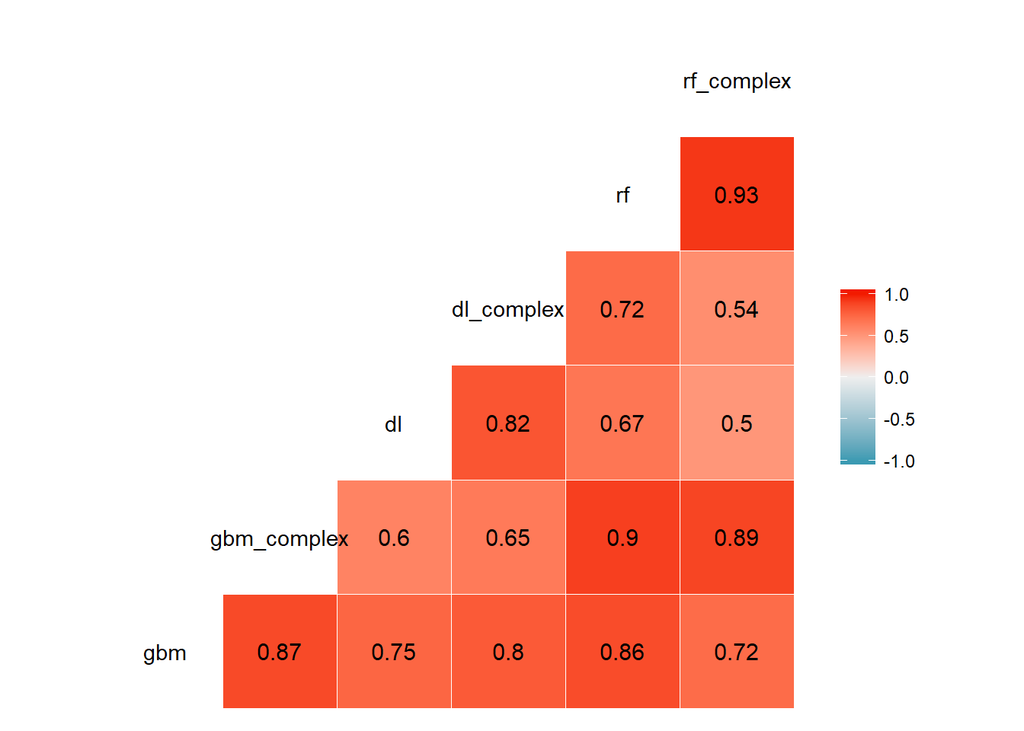

```r
# inspect test set correlations of scores
predictions <- data.table(
  "gbm" = as.data.frame(h2o.predict(gbm_model, newdata = data_test)$Y)$Y,
  "gbm_complex" = as.data.frame(h2o.predict(gbm_model_complex, newdata = data_test)$Y)$Y,
  "dl" = as.data.frame(h2o.predict(deeplearning_model, newdata = data_test)$Y)$Y,
  "dl_complex" = as.data.frame(h2o.predict(deeplearning_model_complex, newdata = data_test)$Y)$Y,
  "rf" = as.data.frame(h2o.predict(randomforest_model, newdata = data_test)$Y)$Y,
  "rf_complex" = as.data.frame(h2o.predict(randomforest_model_complex, newdata = data_test)$Y)$Y
)
ggcorr(predictions, label = TRUE, label_round = 2)
```

### 2.4 Create a stacked ensemble model from the base learners. Experiment with at least two different ensembling meta learners.

#### 2.4.1 `GLM` model as meta learner

The default meta learner is a `GLM` model, now I am tranining a `GLM` meta learner with default settings.

```r
ensemble_model_glm <- h2o.stackedEnsemble( # built in h2o function, it estimates the meta model
                                       # on the scores estimated by the previously trained models
  X, y,
  training_frame = data_train,
  base_models = list(gbm_model,
                     gbm_model_complex,
                     deeplearning_model,
                     deeplearning_model_complex,
                     randomforest_model,
                     randomforest_model_complex))
```

#### 2.4.2 `GBM` model as meta learner

Now I am experimenting with `GBM` as the meta model, with default parameters.

```r
ensemble_model_gbm <- h2o.stackedEnsemble(
  X, y,
  training_frame = data_train,
  metalearner_algorithm = "gbm",
  base_models = list(gbm_model,
                     gbm_model_complex,
                     deeplearning_model,
                     deeplearning_model_complex,
                     randomforest_model,
                     randomforest_model_complex))
```

#### 2.4.3 `drf` model as meta learner

Now I am experimenting with `drf` (random forest) as the meta model, with default parameters.

```r
ensemble_model_drf <- h2o.stackedEnsemble(
  X, y,
  training_frame = data_train,
  metalearner_algorithm = "drf",
  base_models = list(gbm_model,
                     gbm_model_complex,
                     deeplearning_model,
                     deeplearning_model_complex,
                     randomforest_model,
                     randomforest_model_complex))
```

#### 2.4.4 `deeplearning` model as meta learner

Now I am experimenting with `deeplearning` as the meta model, with default parameters.

```r
ensemble_model_dl <- h2o.stackedEnsemble(
  X, y,
  training_frame = data_train,
  metalearner_algorithm = "deeplearning",
  base_models = list(gbm_model,
                     gbm_model_complex,
                     deeplearning_model,
                     deeplearning_model_complex,
                     randomforest_model,
                     randomforest_model_complex))
```

### 2.5 Evaluate ensembles on validation set. Did it improve prediction?

```r
# validation set performance

# checking performance of ensemble models on validation set
validation_performances <- list(
  "glm" = print(h2o.auc(h2o.performance(ensemble_model_glm, newdata = data_valid))),
  "gbm" = print(h2o.auc(h2o.performance(ensemble_model_gbm, newdata = data_valid))),
  "rf" = print(h2o.auc(h2o.performance(ensemble_model_drf, newdata = data_valid))),
  "dl" = print(h2o.auc(h2o.performance(ensemble_model_dl, newdata = data_valid)))
)
```

```
## [1] 0.7144245
## [1] 0.6908333
## [1] 0.6776822
## [1] 0.6899388
```

```r
validation_performances
```

```
## $glm
## [1] 0.7144245
##
## $gbm
## [1] 0.6908333
##
## $rf
## [1] 0.6776822
##
## $dl
## [1] 0.6899388
```

### 2.6 Evaluate the best performing model on the test set. How does performance compare to that of the validation set?

```r
print(h2o.auc(h2o.performance(ensemble_model_glm, newdata = data_test)))
```

```
## [1] 0.7139611
```

### 2.7 Extra experiment

Meta-learning can also be built upon same-family, different hyperparameter models via a grid of hyperparameters. I am experimenting with a `GBM` model. First I am building models with different parameters for `learn_rate` and `max_depth`.

```r
learn_rate_opt <- c(0.1, 0.3)
max_depth_opt <- c(3, 5, 7) # we can use cross-validation to choose the best hyperparameter
hyper_params <- list(learn_rate = learn_rate_opt,
                     max_depth = max_depth_opt)

gbm_grid <- h2o.grid(
  x = X, y = y,
  training_frame = data_train,
  algorithm = "gbm",
  ntrees = 100,
  hyper_params = hyper_params,
  seed = 123,
  nfolds = 5,
  keep_cross_validation_predictions = TRUE)
```

Now I am checking the performance of these models on the test set.

```r
# individual test set performances
for (model_id in gbm_grid@model_ids) {
  model <- h2o.getModel(model_id)
  print(model_id)
  print(h2o.auc(h2o.performance(model, newdata = data_test)))
}
```

```
## [1] "Grid_GBM_RTMP_sid_8760_2_model_R_1522787101052_45715_model_0"
## [1] 0.7142336
## [1] "Grid_GBM_RTMP_sid_8760_2_model_R_1522787101052_45715_model_1"
## [1] 0.7055683
## [1] "Grid_GBM_RTMP_sid_8760_2_model_R_1522787101052_45715_model_2"
## [1] 0.7056606
## [1] "Grid_GBM_RTMP_sid_8760_2_model_R_1522787101052_45715_model_4"
## [1] 0.6954283
## [1] "Grid_GBM_RTMP_sid_8760_2_model_R_1522787101052_45715_model_3"
## [1] 0.6929798
## [1] "Grid_GBM_RTMP_sid_8760_2_model_R_1522787101052_45715_model_5"
## [1] 0.6871379
```

```r
# individually none of them reached 0.72, but by stacking them we could improve that
```

Now I am stacking these models.

```r
ensemble_model_grid_gbm <- h2o.stackedEnsemble(
  X, y,
  training_frame = data_train,
  base_models = gbm_grid@model_ids)
```

Now I am evaluating the performance of the stacked model on the test set.

```r
print(h2o.auc(h2o.performance(ensemble_model_grid_gbm, newdata = data_test)))
```

```
## [1] 0.7142761
```

```r
# by stacking we improved the model
```

The stacked model could outperform all the individual models. I noted that the one of the individual models was pretty close to the stacked, but it does not apply to the rest.

## 3. Fashion image classification using `keras`

Take the “Fashion MNIST dataset” where images of fashion items are to be classified in a similar manner to what we saw with handwritten digits (see more here). Images are in exactly the same format as we saw digits: 28x28 pixel grayscale images. The task is to build deep neural net models to predict image classes. The goal is to have as accurate classifier as possible: we are using accuracy as a measure of predictive power.

```r
library(keras)
fashion_mnist <- dataset_fashion_mnist()
x_train <- fashion_mnist$train$x
y_train <- fashion_mnist$train$y
x_test <- fashion_mnist$test$x
y_test <- fashion_mnist$test$y
```

### 3.1 Show some example images from the data.

We are going to classify fashion items, it is an example of multiclass classification. The train data set has 60.000 images with a resolution of 28x28 pixels. We have 10.000 images in the test with the same resolution. We have the following labels for fashion items:

- 0 T-shirt/top
- 1 Trouser
- 2 Pullover
- 3 Dress
- 4 Coat
- 5 Sandal
- 6 Shirt
- 7 Sneaker
- 8 Bag
- 9 Ankle boot

[figure not shown]

```r
show_mnist_image <- function(x) {
  image(1:28, 1:28, t(x)[,nrow(x):1],col=gray((0:255)/255))
}

# showing some example images from the training data

show_mnist_image(x_train[18, , ])
```

```r
y_train[18] # the GT - ground truth - it is a T-shirt/top
```

```
## [1] 0
```

[figure not shown]

```r
show_mnist_image(x_train[19, , ])
```

```r
y_train[19] # it is a shirt
```

```
## [1] 6
```

[figure not shown]

```r
show_mnist_image(x_train[20, , ])
```

```r
y_train[20] # coat
```

```
## [1] 4
```

[figure not shown]

```r
show_mnist_image(x_train[21, , ])
```

```r
y_train[21] # dress
```

```
## [1] 3
```

[figure not shown]

```r
show_mnist_image(x_train[22, , ])
```

```r
y_train[22] # trouser
```

```
## [1] 1
```

### 3.2 Train a fully connected deep network to predict items.

- Normalize the data similarly to what we saw with MNIST.
- Experiment with network architectures and settings (number of hidden layers, number of nodes, activation functions, etc.)
- Explain what you have tried, what worked and what did not. Present a final model.
- Make sure that you use enough epochs so that the validation error starts flattening out - provide a plot about the training history ( plot(history))

I need to reshape and rescale the data so I could work with it. First I need to create vectors of each images. As the resolution is 28x28 pixels, length of each vector will be 28x28 = 784. Every value in the vector represents a pixel, with a number between 0 and 255, represing a shade of grey. I need to rescale them, so they would be between 0 and 1.

```r
# reshaping images
x_train <- array_reshape(x_train, c(dim(x_train)[1], 784)) # creating vector with a length of 784 features of matrices sized 28x28
# every pixel is a feature
x_test <- array_reshape(x_test, c(dim(x_test)[1], 784))

# rescaling
x_train <- x_train / 255 # resclaing it so it can be between 0 and 1
x_test <- x_test / 255

# one-hot encoding of the target variable
y_train <- to_categorical(y_train, 10) # it is a Keras function, this is the way that Keras accepts outcome variables
y_test <- to_categorical(y_test, 10)
```

### 3.2.1 Benchmark model

First I am going to build a benchmark and will try to improve it.

First step is to define the model. The core data structure of Keras is a model, a way to organize layers. The simplest type of model is the Sequential model, a linear stack of layers. I begin by creating a sequential model and then adding layers using the pipe (%>%) operator.

```r
model <- keras_model_sequential() # sequental, because we go layer by layer
model %>%
  layer_dense(units = 128, activation = 'relu', input_shape = c(784)) %>%
  layer_dropout(rate = 0.3) %>%
  layer_dense(units = 10, activation = 'softmax')
```

The `input_shape` argument to the first layer specifies the shape of the input data (a length 784 numeric vector representing a grayscale image). The final layer outputs a length 10 numeric vector (probabilities for each digit) using a softmax activation function.

By using the `summary()` function I can print the details of the model, please find it below.

```r
summary(model)
```

```
## ___________________________________________________________________________
## Layer (type)                     Output Shape                  Param #
## ===========================================================================
## dense_1 (Dense)                  (None, 128)                   100480
## ___________________________________________________________________________
## dropout_1 (Dropout)              (None, 128)                   0
## ___________________________________________________________________________
## dense_2 (Dense)                  (None, 10)                    1290
## ===========================================================================
## Total params: 101,770
## Trainable params: 101,770
## Non-trainable params: 0
## ___________________________________________________________________________
```

Next step is to compile the model with:

- an appropriate loss function, `categorical_crossentropy` in this case,
- an optimizer, this time it `optimizer_rmsprop()`, it divides the gradient by a running average of its recent magnitude. It is recommended to leave the parameters of this optimizer at their default values (except the learning rate, which can be freely tuned).
- and metrics, `accuracy` was chosen in this exercise.

```r
model %>% compile(
  loss = 'categorical_crossentropy', # defining a loss function
  optimizer = optimizer_rmsprop(),
  metrics = c('accuracy') # chossing metrics
)
```

The next step is training and evaluation. I need to use the `fit()` function to train the model for 30 epochs using batches of 128 images:

```r
history <- model %>% fit(
  x_train, y_train, # defining the training and the outcome data-sets
  epochs = 30, batch_size = 128, # batc_size defines the number of samples that are going to be propagated through the network
  validation_split = 0.2 # 20% of training set will be set aside for validation
)
```

The `history` object returned by `fit()` includes loss and accuracy metrics which I am plotting below:

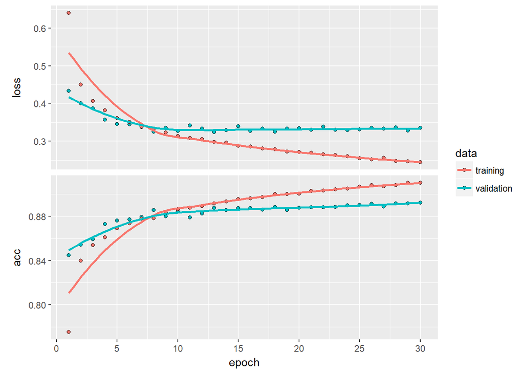

```r
plot(history)
```

```r
model %>% evaluate(x_test, y_test)
```

```
## $loss
## [1] 0.3714084
##
## $acc
## [1] 0.8841
```

### 3.2.2 Trying to improve the model

Now I am trying to improve the model by adding another layer to it and experimenting with the network architecture and settings. In this new layer I am setting:

```r
model <- keras_model_sequential()
model %>%
  layer_dense(units = 256, activation = 'relu', input_shape = c(784)) %>%
  layer_dropout(rate = 0.55) %>%
  layer_dense(units = 128, activation = 'relu') %>%
  layer_dropout(rate = 0.3) %>%
  layer_dense(units = 10, activation = 'softmax')
```

(Note: I experimented with different architectures, with 128 and 512 units on the first layer, but both gave significantly worse results than with 256. I also experimented with different dropout rates, 0.55 seemed to be the optimal choice. ``0.8`, `0.4` and `0.6` gave worse results.)

We can see that we have more layers.

```r
summary(model)
```

```
## ___________________________________________________________________________
## Layer (type)                     Output Shape                  Param #
## ===========================================================================
## dense_3 (Dense)                  (None, 256)                   200960
## ___________________________________________________________________________
## dropout_2 (Dropout)              (None, 256)                   0
## ___________________________________________________________________________
## dense_4 (Dense)                  (None, 128)                   32896
## ___________________________________________________________________________
## dropout_3 (Dropout)              (None, 128)                   0
## ___________________________________________________________________________
## dense_5 (Dense)                  (None, 10)                    1290
## ===========================================================================
## Total params: 235,146
## Trainable params: 235,146
## Non-trainable params: 0
## ___________________________________________________________________________
```

```r
model %>% compile(
  loss = 'categorical_crossentropy',
  optimizer = optimizer_adamax(),
  metrics = c('accuracy')
)
```

(Note: I experimented with different loss functions, such as `mean_squared_error`, `categorical_crossentropy`, `kullback_leibler_divergence`, `cosine_proximity`, `mean_squared_logarithmic_error`, `categorical_hinge`, `squared_hinge`, `poisson` and `logcosh`, but couldn’t make test performance better than 90%. I tried other optimizers, but found `optimizer_adamax()` the best one. `epochs` was set to 100 in early trials, but I found 75 more than enough in all cases.)

```r
history <- model %>% fit(
  x_train, y_train, # defining the training and the outcome data-sets
  epochs = 75, batch_size = 128,
  validation_split = 0.2 # 20% of training set will be set aside for validation
)
```

The `history` object returned by `fit()` includes loss and accuracy metrics which I am plotting below:

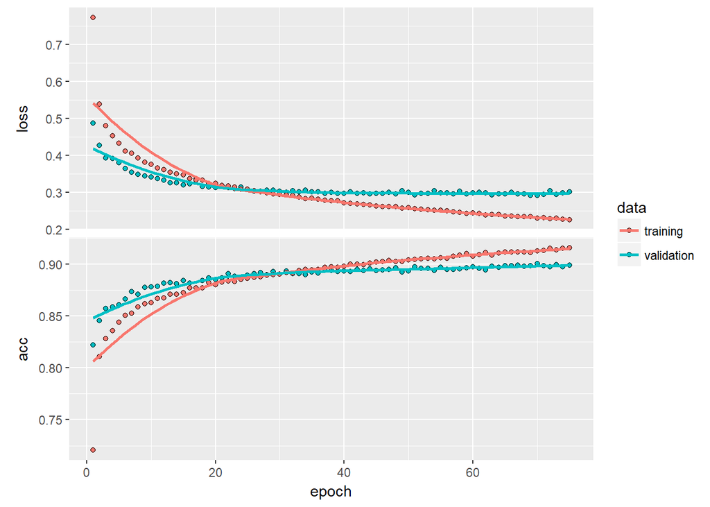

```r
plot(history)
```

### 3.3 Evaluate the model on the test set. How does test error compare to validation error?

```r
model %>% evaluate(x_test, y_test)
```

```
## $loss
## [1] 0.3282842
##
## $acc
## [1] 0.8906
```

I tried to improve the model, but couldn’t achieve significant improvement compared to the first model with less layers and `epochs`.

### 3.4 Try building a convolutional neural network and see if you can improve test set performance.

```r
mnist <- dataset_mnist()
x_train <- mnist$train$x
y_train <- mnist$train$y
x_test <- mnist$test$x
y_test <- mnist$test$y

x_train <- array_reshape(x_train, c(nrow(x_train), 28, 28, 1))
x_test <- array_reshape(x_test, c(nrow(x_test), 28, 28, 1))

# rescale
x_train <- x_train / 255
x_test <- x_test / 255

# one-hot encoding of the target variable
y_train <- to_categorical(y_train, 10)
y_test <- to_categorical(y_test, 10)
```

This `layer_conv_2d` layer creates a convolution kernel that is convolved with the layer input to produce a tensor of outputs.

```r
cnn_model <- keras_model_sequential()
cnn_model %>%
  layer_conv_2d(filters = 32,
                kernel_size = c(3, 3), # An integer or list of 2 integers, specifying the width and height of the 2D convolution window
                activation = 'relu',
                input_shape = c(28, 28, 1)) %>%
  layer_max_pooling_2d(pool_size = c(2, 2)) %>%
  layer_dropout(rate = 0.25) %>%
  layer_flatten() %>%
  layer_dense(units = 32, activation = 'relu') %>%
  layer_dense(units = 10, activation = 'softmax')
# these works better than the previously introduced NNs
```

```r
summary(cnn_model)
```

```
## ___________________________________________________________________________
## Layer (type)                     Output Shape                  Param #
## ===========================================================================
## conv2d_1 (Conv2D)                (None, 26, 26, 32)            320
## ___________________________________________________________________________
## max_pooling2d_1 (MaxPooling2D)   (None, 13, 13, 32)            0
## ___________________________________________________________________________
## dropout_4 (Dropout)              (None, 13, 13, 32)            0
## ___________________________________________________________________________
## flatten_1 (Flatten)              (None, 5408)                  0
## ___________________________________________________________________________
## dense_6 (Dense)                  (None, 32)                    173088
## ___________________________________________________________________________
## dense_7 (Dense)                  (None, 10)                    330
## ===========================================================================
## Total params: 173,738
## Trainable params: 173,738
## Non-trainable params: 0
## ___________________________________________________________________________
```

```r
cnn_model %>% compile(
  loss = 'categorical_crossentropy',
  optimizer = optimizer_rmsprop(),
  metrics = c('accuracy')
)
```

```r
history <- cnn_model %>% fit(
  x_train, y_train,
  epochs = 20,
  batch_size = 128,
  validation_split = 0.2
)
```

```r
cnn_model %>% evaluate(x_test, y_test)
```

```
## $loss
## [1] 0.05532084
##
## $acc
## [1] 0.9849
```